## Loading and preprocessing the data

I downloaded the zipped data from the site and unzipped in my working directory.

I set the working directory for the R using the following command

```r
setwd("/users/dipendra/desktop/coursera/RepData_PeerAssessment1")
```

Next, Read the data from the csv file and store that in a variable named ‘data’.

```r
data <- read.csv("activity.csv")
dim (data)
```

```
## [1] 17568     3
```

Create dataset excluding the missing values (NA)

```r
subdata = data[!is.na(data$steps), ]
dim(subdata)
```

```
## [1] 15264     3
```

## What is mean total number of steps taken per day?

Ignoring the missing values in the dataset

1. Making a histogram of the total number of steps taken each day

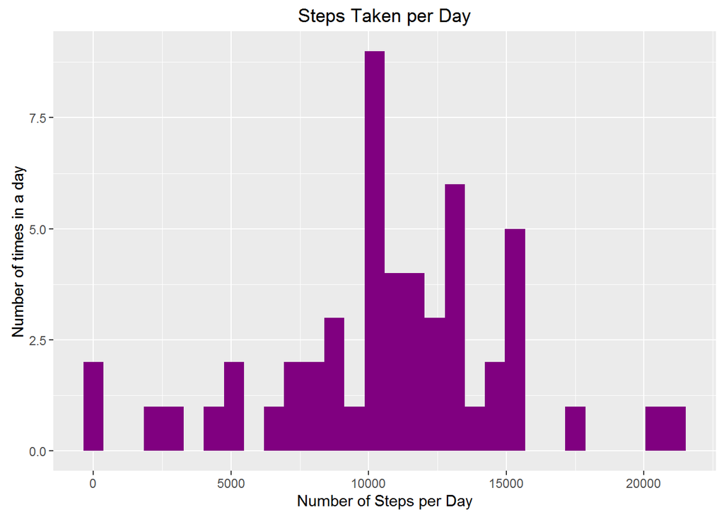

```r
#group for day
num.steps.date <- aggregate(subdata$steps, list(subdata$date), sum)
colnames(num.steps.date) <- c("date", "steps")

library(ggplot2)
#hist
ggplot(data=num.steps.date, aes(x=steps)) +
  geom_histogram(fill="#800080") +
  ggtitle("Steps Taken per Day") +
  labs(x="Number of Steps per Day", y="Number of times in a day")
```

2. Calculating and reporting the mean and median total number of steps taken per day

```r
#mean
steps_mean   <- mean(num.steps.date$steps)
steps_mean
```

```
## [1] 10766.19
```

```r
#median
steps_median <- median(num.steps.date$steps)
steps_median
```

```
## [1] 10765
```

## What is the average daily activity pattern?

1. Make a time series plot (i.e. type = “l”) of the 5-minute interval (x-axis) and the average number of steps taken, averaged across all days (y-axis)

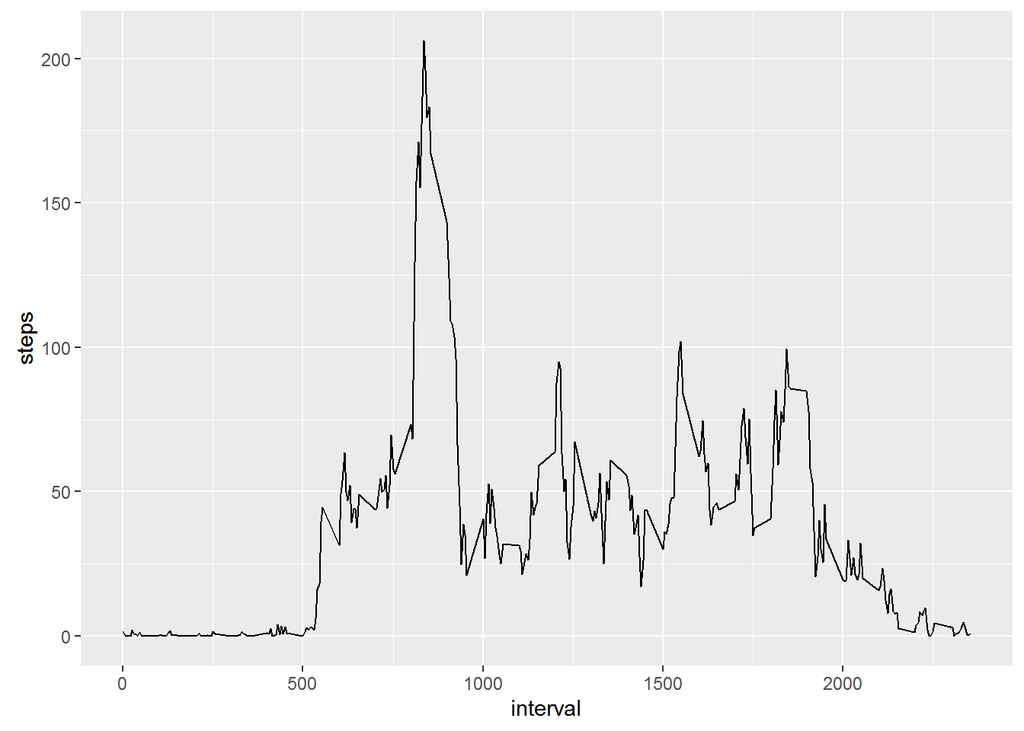

```r
steps_per_interval <- aggregate(subdata$steps,
                                by = list(interval = as.factor(subdata$interval)),
                                FUN=mean, na.rm=TRUE)

steps_per_interval$interval <-
        as.integer(levels(steps_per_interval$interval)[steps_per_interval$interval])

colnames(steps_per_interval) <- c("interval", "steps")

ggplot(data=steps_per_interval, aes(x=interval, y=steps)) +
    geom_line()
```

2. Which 5-minute interval, on average across all the days in the dataset, contains the maximum number of steps?

```r
#Maximum interval
max_interval <- steps_per_interval[which.max(steps_per_interval$steps),]
max_interval
```

```
##     interval    steps
## 104      835 206.1698
```

## Imputing missing values

1. Calculate and report the total number of missing values in the dataset (i.e. the total number of rows with NAs)

```r
vals.is.na <- sum(is.na(data$steps))
vals.is.na
```

```
## [1] 2304
```

2. Devise a strategy for filling in all of the missing values in the dataset. The strategy does not need to be sophisticated. For example, you could use the mean/median for that day, or the mean for that 5-minute interval, etc.

```r
#average number of steps as a function of range
steps.iterval <- aggregate(steps ~ interval, data , FUN = mean)

head(data)
```

```
##   steps       date interval
## 1    NA 2012-10-01        0
## 2    NA 2012-10-01        5
## 3    NA 2012-10-01       10
## 4    NA 2012-10-01       15
## 5    NA 2012-10-01       20
## 6    NA 2012-10-01       25
```

```r
#change value NA
for (i in 1:nrow(data)){
     tmp <- data$steps[i]
     if(is.na(tmp)){
         for(j in 1:nrow(steps.iterval)){
             if(data$interval[i] == steps.iterval$interval[j]){
                 data$steps[i] = steps.iterval$steps[j]
                 break
             }
         }
     }
 }

head(data)
```

```
##       steps       date interval
## 1 1.7169811 2012-10-01        0
## 2 0.3396226 2012-10-01        5
## 3 0.1320755 2012-10-01       10
## 4 0.1509434 2012-10-01       15
## 5 0.0754717 2012-10-01       20
## 6 2.0943396 2012-10-01       25
```

3. Create a new dataset that is equal to the original dataset but with the missing data filled in.

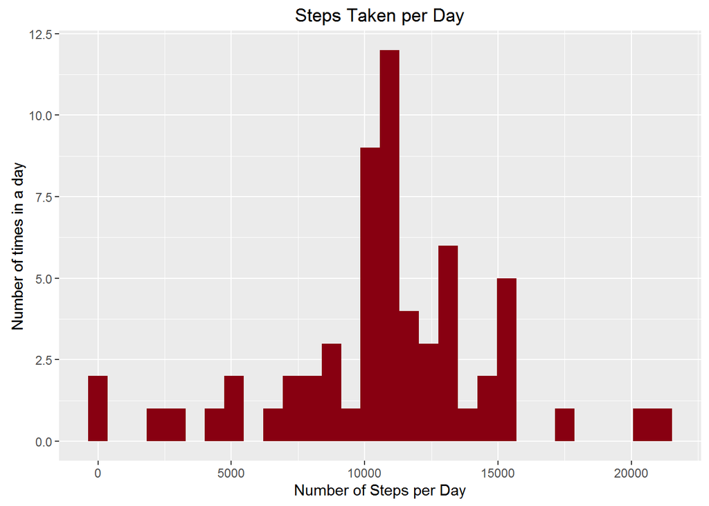

```r
#group for day
new.num.steps.date <- aggregate(data$steps, list(data$date), sum)
colnames(new.num.steps.date) <- c("date", "steps")

library(ggplot2)
#create hist
ggplot(data=new.num.steps.date, aes(x=steps)) +
  geom_histogram(fill="#880011") +
  ggtitle("Steps Taken per Day") +
  labs(x="Number of Steps per Day", y="Number of times in a day")
```

4. Make a histogram of the total number of steps taken each day and Calculate and report the mean and median total number of steps taken per day. Do these values differ from the estimates from the first part of the assignment? What is the impact of imputing missing data on the estimates of the total daily number of steps?

```r
#mean
new_steps_mean   <- mean(new.num.steps.date$steps)
new_steps_mean
```

```
## [1] 10766.19
```

```r
# median
new_steps_median <- median(new.num.steps.date$steps)
new_steps_median
```

```
## [1] 10766.19
```

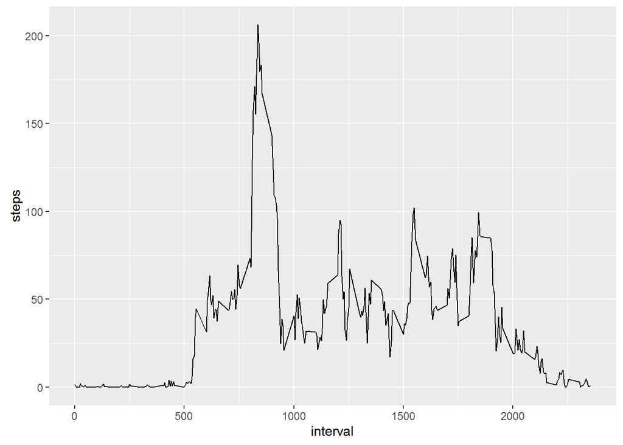

```r
new_steps_per_interval <- aggregate(data$steps,
                                by = list(interval = as.factor(data$interval)),
                                FUN=mean, na.rm=TRUE)

new_steps_per_interval$interval <-
        as.integer(levels(new_steps_per_interval$interval)[new_steps_per_interval$interval])

colnames(new_steps_per_interval) <- c("interval", "steps")

ggplot(data=new_steps_per_interval, aes(x=interval, y=steps)) +
    geom_line()
```

```r
max_interval <- new_steps_per_interval[which.max(new_steps_per_interval$steps),]
max_interval
```

```
##     interval    steps
## 104      835 206.1698
```

## Are there differences in activity patterns between weekdays and weekends?

1. Create a new factor variable in the dataset with two levels – “weekday” and “weekend” indicating whether a given date is a weekday or weekend day.

```r
# convert date from string to Date class
data$date <- as.Date(data$date, "%Y-%m-%d")

# add a new column indicating day of the week
data$day <- weekdays(data$date)

# add a new column called day type and initialize to weekday
data$day_type <- c("weekday")

# If day is Saturday or Sunday, make day_type as weekend
for (i in 1:nrow(data)){
  if (data$day[i] == "Saturday" || data$day[i] == "Sunday"){
    data$day_type[i] <- "weekend"
  }
}

# convert day_time from character to factor
data$day_type <- as.factor(data$day_type)

# aggregate steps as interval to get average number of steps in an interval across all days
table_interval_steps_imputed <- aggregate(steps ~ interval+day_type, data, mean)
```

2. Make a panel plot containing a time series plot (i.e. type = “l”) of the 5-minute interval (x-axis) and the average number of steps taken, averaged across all weekday days or weekend days (y-axis). The plot should look something like the following, which was created using simulated data:

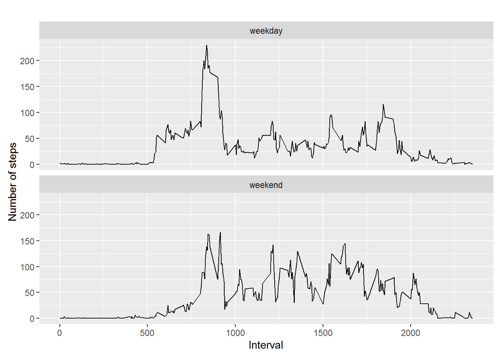

```r
# make the panel plot for weekdays and weekends

library(ggplot2)

qplot(interval, steps, data=table_interval_steps_imputed, geom=c("line"), xlab="Interval",
      ylab="Number of steps", main="") + facet_wrap(~ day_type, ncol=1)
```